# Definitions

[figure not shown]

## Parallelogram

Both pairs of opposite sides are parallel.

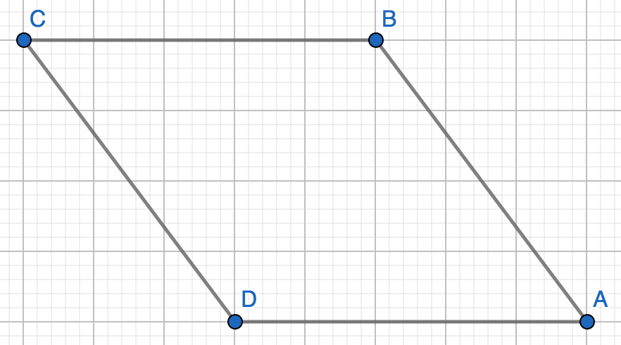

**Fig. 1:** Parallelogram

- $AB\parallel DC$
- $CB\parallel DA$

## Rhombus

Parallelogram whose sides are all the same length.

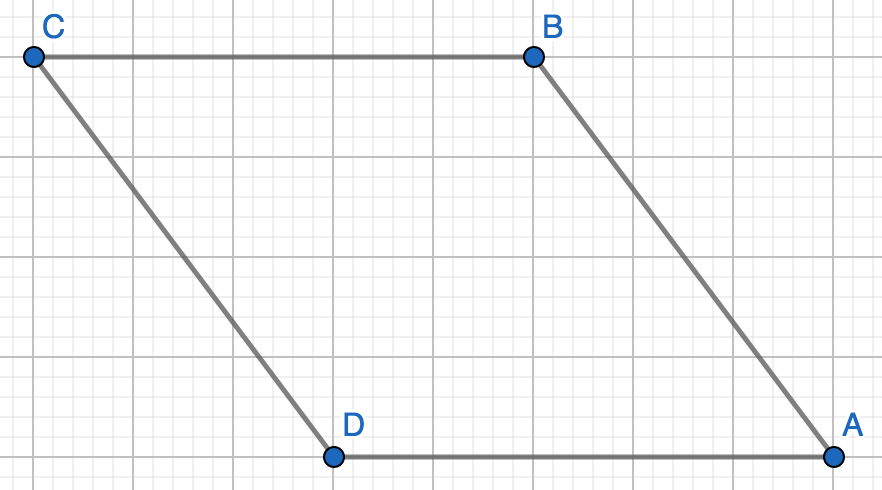

**Fig. 2:** Rhombus

- $\overline{AB}=\overline{BC}=\overline{CD}=\overline{DA}$

## Isometry

Rotations, reflections, translations, and compositions of these that preserve distance, length, and angle measure. “rigid motion”

### Translations

Move all the points across a vector $\vec{v}$.

Notation: $\tau_{\text{start point,end point}}$

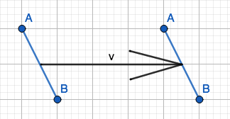

**Fig. 3:** Translation of line AB along vector v.

### Rotations

Pick a center O (origin), $\theta$ (angle), takes P to P’ on a circle on a circle with center O and radius $\overline{OP}$ with $\angle POP'=\theta$.

Notation: $R_{O,\theta}$

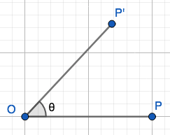

**Fig. 4:** Rotation of line OP.

### Reflections

Mirror of a shape across a line.

Pick line b.

- Points on B don’t move.
- Points not on b, P, go to P’ where b is perpendicular to bisector of $\overline{PP'}$.
- Midpoint m of PP’ on b make right angle $\overline{PP'}$

Notation: $r_{b}$

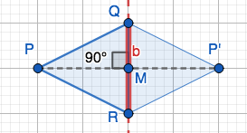

**Fig. 5:** Triangle QPR reflected across line b.

### Composition

Combinations of rotations, reflections, and translations.

## Symmetry

An isometry that sends a geometric figure to itself.

Example:

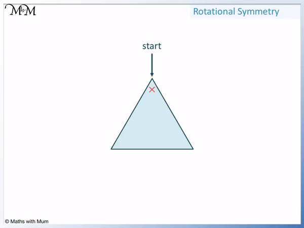

## Group

The set of isometries with composition is a group.

0. Closure
   - Order doesn’t matter
   - $ab=ba$
1. Associativity
   - Parentheses don’t matter
   - $(ab)c=a(bc)$
2. Identity
   - Anything combined with the identity equals itself.
   - $ea=ae=a$
3. Inverses
   - undoes isometry
   - $f^{-1}(f(a))=a$